# Sequential Monte Carlo for Response Adaptive Randomized Clinical Trials

This is a demo for package SMC.RAR which uses sequential Monte Carlo (SMC) for performing Bayesian updates within a Response Adaptive Randomized (RAR) clinical trial which in turn facilitates simulation of RAR trials in a Bayesian framework with non-conjugate models.

In this demo we consider two example scenarios where we simulate a RAR trial where patients are enrolled one at a time and the results (posterior distribution of effect sizes) are updated after every single outcome (assumed to be instantaneous) is available. After an initail sample of patients the allocation probabilities of patients to different arms are adjusted according to the performance of teh corresponding intervention. The trial is stopped if one of the trial arms is superior to the others with probability 0.95 given the data observed so far. Also a trial arm is dropped if its probability of being superior falls below 0.01.

## Example 1

Binary outcomes: Consider a four arm RAR design where each patient is given one of four competing treatments. The allocation is decided by generating $x_n$ from

$$x_n \sim \text{Multinomial}(1, \boldsymbol{\rho} = (\rho_1, \ldots, \rho_L)),$$
where
$$\rho_1 = \ldots = \rho_L = \frac{1}{L} \hskip 144pt \text{for} \hskip 5pt n \leq n_0;$$
and
$$\rho_l = \text{P}(\theta_l = \max(\theta_1, \ldots, \theta_L)\mid \mathbf{y}_n), \hskip 5pt l = 1, \ldots, L \hskip 20pt \text{for} \hskip 5pt n > n_0.$$

```r
rar1 = RAR_sim(nt = 4, theta0 = c(0, 0.5, -0.4, 1.2), response.type = 'binary')
```

## Plot the results

Now we can look at the simulated trial data:

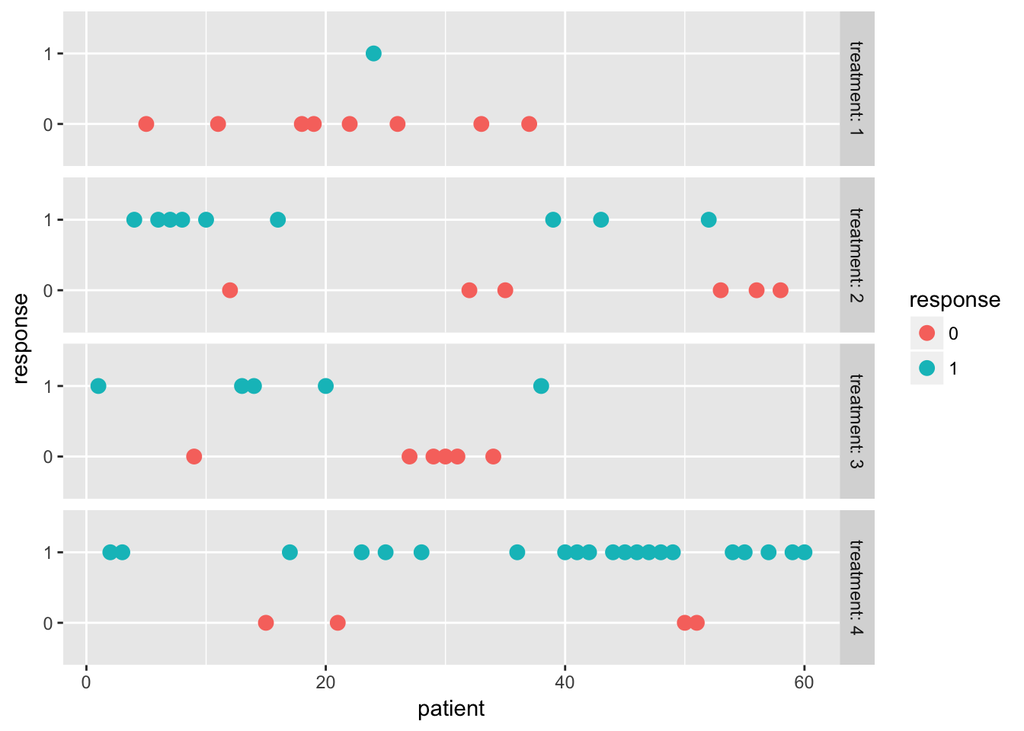

```r
data_plot(rar1)
```

If patient $n$ receives treatment $l$ a dot appears in row $l$ for patient $n$. If the dot is green the response is positive and if it is red the response is negative. The allocations are balanced for the four arms up to 40 patients. We can look at the evolution of the probability of superiority for each arm corresponding to this data:

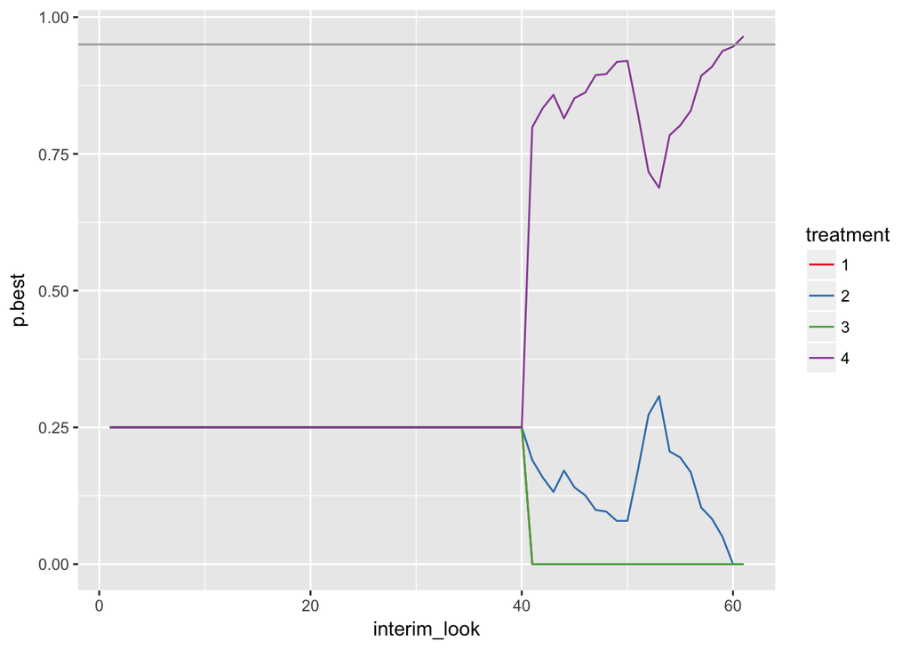

```r
psup_plot(rar1)
```

Finally, we can see how the posterior distribution of the effect sizes corresponding to different arms looks like at 5 snapshots through the course of the trial:

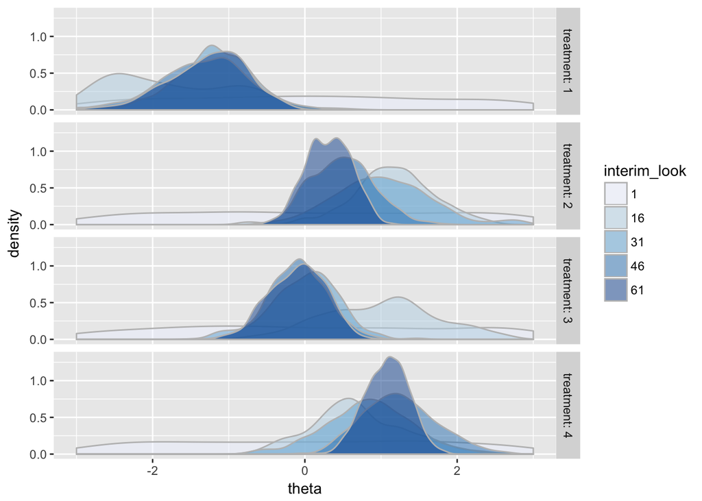

```r
post_plot(rar1)
```

## Example 2

The effect sizes for the data generating process are assumed to be $\boldsymbol{\theta} = (0, 1.5, 1.2, 1, 0)$.

```r
rar2 = RAR_sim(nt = 5, theta0 = c(0, 1.5, 1.2, 1, 0), response.type = 'binary')
```

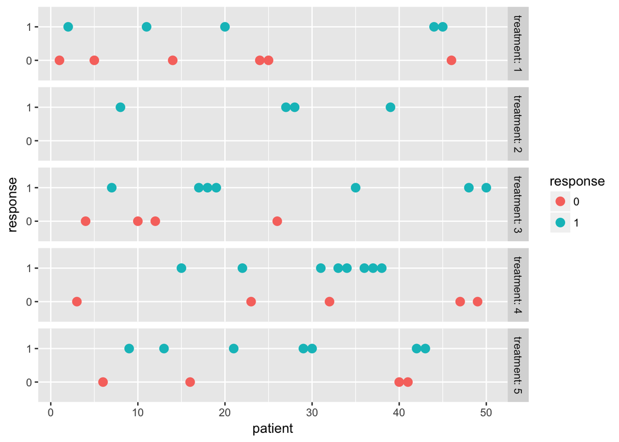

```r
data_plot(rar2)
```

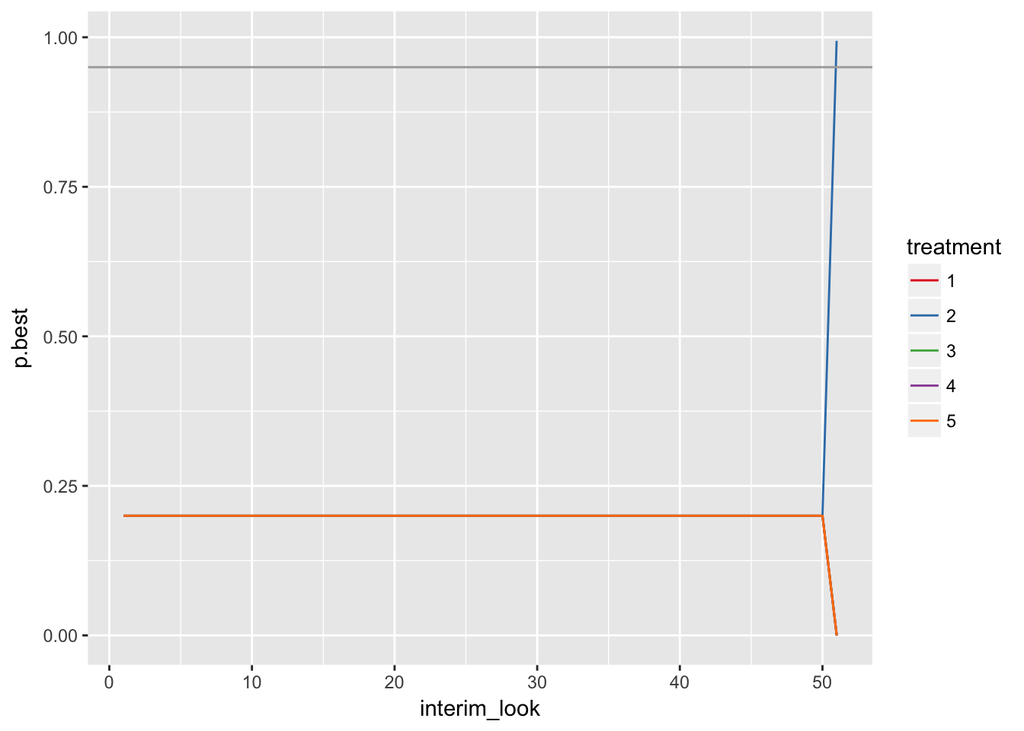

```r
psup_plot(rar2)
```

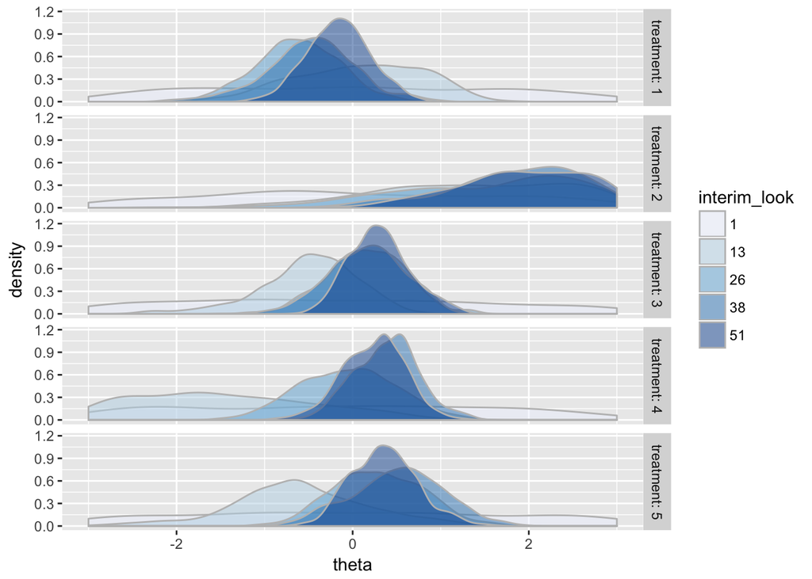

```r
post_plot(rar2)
```